# AOA analysis

Joshua Johnson

# Packages, data loading etc.

```r
library(tidyverse)
library(dplyr)
library(ggplot2)
library(cowplot)
library(reshape2)
library(rstatix)
library(ggpubr)
library(nlme)
```

# Basic statistics and data mangling

| type | id | n | avg.qty | sd.qty |
| --- | --- | --- | --- | --- |
| rhizo | 198 | 3 | 11395.070 | 665.58412 |
| rhizo | 201 | 3 | 13924.053 | 1346.25453 |
| rhizo | 206 | 3 | 4522.731 | 224.82350 |
| rhizo | 212 | 3 | 8754.031 | 459.87191 |
| rhizo | 216 | 3 | 12770.146 | 92.25548 |
| rhizo | 224 | 3 | 7830.966 | 627.70218 |
| rhizo | 226 | 3 | 6921.189 | 1466.57428 |
| rhizo | 226 rhizo rep | 3 | 19661.426 | 1430.91483 |
| rhizo | 232 | 3 | 10559.661 | 692.04476 |
| rhizo | 234 | 3 | 12719.788 | 1627.74666 |

[output cut: 72 more lines]

| type | id | n | avg.qty | sd.qty | dna_conc | unit | qty_undil | qty_ul | qty_ng |
| --- | --- | --- | --- | --- | --- | --- | --- | --- | --- |
| rhizo | 198 | 3 | 11395.070 | 665.58412 | 35.82 | DNA[ng_ul] | 4558028 | 569753.5 | 15906.016 |
| rhizo | 201 | 3 | 13924.053 | 1346.25453 | 38.13 | DNA[ng_ul] | 5569621 | 696202.7 | 18258.659 |
| rhizo | 206 | 3 | 4522.731 | 224.82350 | 47.48 | DNA[ng_ul] | 1809092 | 226136.6 | 4762.775 |
| rhizo | 212 | 3 | 8754.031 | 459.87191 | 35.07 | DNA[ng_ul] | 3501613 | 437701.6 | 12480.797 |
| rhizo | 216 | 3 | 12770.146 | 92.25548 | 52.80 | DNA[ng_ul] | 5108058 | 638507.3 | 12092.941 |
| rhizo | 224 | 3 | 7830.966 | 627.70218 | 38.58 | DNA[ng_ul] | 3132386 | 391548.3 | 10148.997 |
| rhizo | 226 | 3 | 6921.189 | 1466.57428 | 50.33 | DNA[ng_ul] | 2768476 | 346059.5 | 6875.809 |
| rhizo | 232 | 3 | 10559.661 | 692.04476 | 60.16 | DNA[ng_ul] | 4223864 | 527983.0 | 8776.314 |
| rhizo | 234 | 3 | 12719.788 | 1627.74666 | 61.10 | DNA[ng_ul] | 5087915 | 635989.4 | 10408.992 |
| rhizo | 237 | 3 | 9983.888 | 775.09152 | 43.06 | DNA[ng_ul] | 3993555 | 499194.4 | 11592.995 |

[output cut: 70 more lines]

| type | id | qty_ng | unit | treatment | fert | fung | block | row | time |
| --- | --- | --- | --- | --- | --- | --- | --- | --- | --- |
| rhizo | 198 | 15906.016 | GeneCopies/ngDNA | H00 | no | no | b | 1 | t2 |
| rhizo | 201 | 18258.659 | GeneCopies/ngDNA | H00 | no | no | c | 1 | t2 |
| rhizo | 206 | 4762.775 | GeneCopies/ngDNA | H01 | yes | no | b | 1 | t2 |
| rhizo | 212 | 12480.797 | GeneCopies/ngDNA | HP0 | no | yes | b | 1 | t2 |
| rhizo | 216 | 12092.941 | GeneCopies/ngDNA | HP1 | yes | yes | b | 1 | t2 |
| rhizo | 224 | 10148.997 | GeneCopies/ngDNA | HP0 | no | yes | c | 2 | t2 |
| rhizo | 226 | 6875.809 | GeneCopies/ngDNA | HP0 | no | yes | e | 2 | t2 |
| rhizo | 232 | 8776.314 | GeneCopies/ngDNA | H00 | no | no | d | 2 | t2 |
| rhizo | 234 | 10408.992 | GeneCopies/ngDNA | HP1 | yes | yes | c | 2 | t2 |
| rhizo | 237 | 11592.995 | GeneCopies/ngDNA | H01 | yes | no | c | 2 | t2 |

[output cut: 70 more lines]

The data preparation is finished for the AOA gene copy data. We have worked with the raw quantity values used qPCR machine (standardized on the individual runs standard curve), did summary statistics (averaging the technical replicates) and calculated gene copy number per nanogram DNA.

Now we move on to the statistical modelling and checking for significance.

# Statistical modelling and sig. testing

## Rhizo

### Checking data balance

| fert | fung | time | variable | n | mean | sd |
| --- | --- | --- | --- | --- | --- | --- |
| no | no | t2 | qty_ng | 5 | 13361.43 | 3744.097 |
| no | no | t3 | qty_ng | 5 | 20160.87 | 5139.878 |
| no | yes | t2 | qty_ng | 5 | 10443.74 | 2389.616 |
| no | yes | t3 | qty_ng | 5 | 17482.21 | 4265.974 |
| yes | no | t2 | qty_ng | 5 | 10147.70 | 3350.468 |
| yes | no | t3 | qty_ng | 5 | 23389.89 | 4692.844 |
| yes | yes | t2 | qty_ng | 5 | 11059.26 | 1021.363 |
| yes | yes | t3 | qty_ng | 5 | 11734.43 | 2761.778 |

We have a balanced dataset (n is the same for each group). Moving on to a boxplot to visually inspect groups and look for outliers.

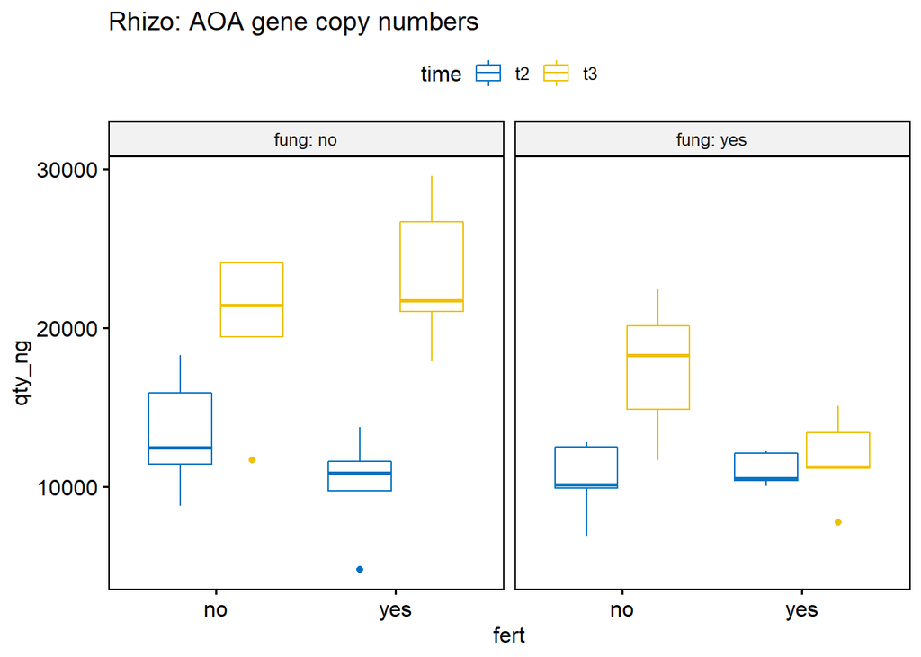

We have each one outlier in ‘[fert:no|fung:no|time:t3]’, ‘[fert:yes|fung:no|time:t2]’ and ‘[fert:yes|fung:yes|time:t3]’. Let’s check if they are extreme:

| fert | fung | time | id | qty_ng | block | row | is.outlier | is.extreme |
| --- | --- | --- | --- | --- | --- | --- | --- | --- |
| no | no | t3 | 355 | 11676.078 | e | 3 | TRUE | FALSE |
| yes | no | t2 | 206 | 4762.775 | b | 1 | TRUE | FALSE |
| yes | yes | t3 | 365 | 7746.487 | e | 4 | TRUE | FALSE |

According to the definition

> Values above Q3 + 1.5xIQR or below Q1 - 1.5xIQR are considered as outliers. Values above Q3 + 3xIQR or below Q1 - 3xIQR are considered as extreme points (or extreme outliers).

there are no extreme outliers in this dataset.